# 8.1 Exercise

Joaquin Rodriguez

10/15/2017

```
##  Hlavac, Marek (2015). stargazer: Well-Formatted Regression and Summary Statistics Tables.
```

```
##  R package version 5.2. http://CRAN.R-project.org/package=stargazer
```

## Campbell Model

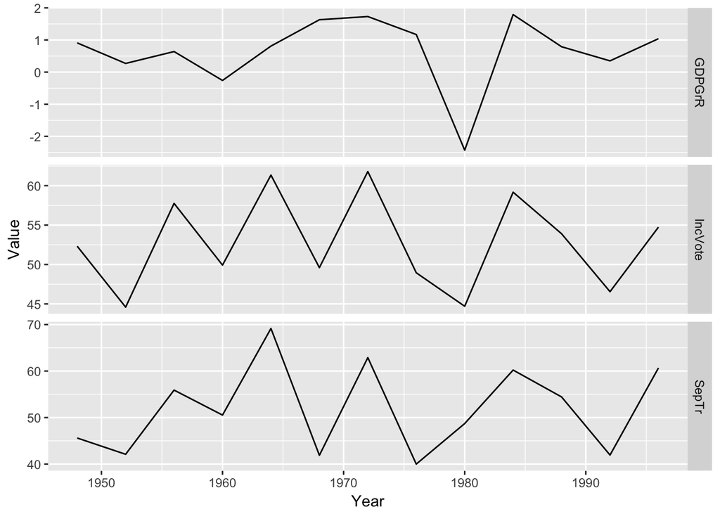

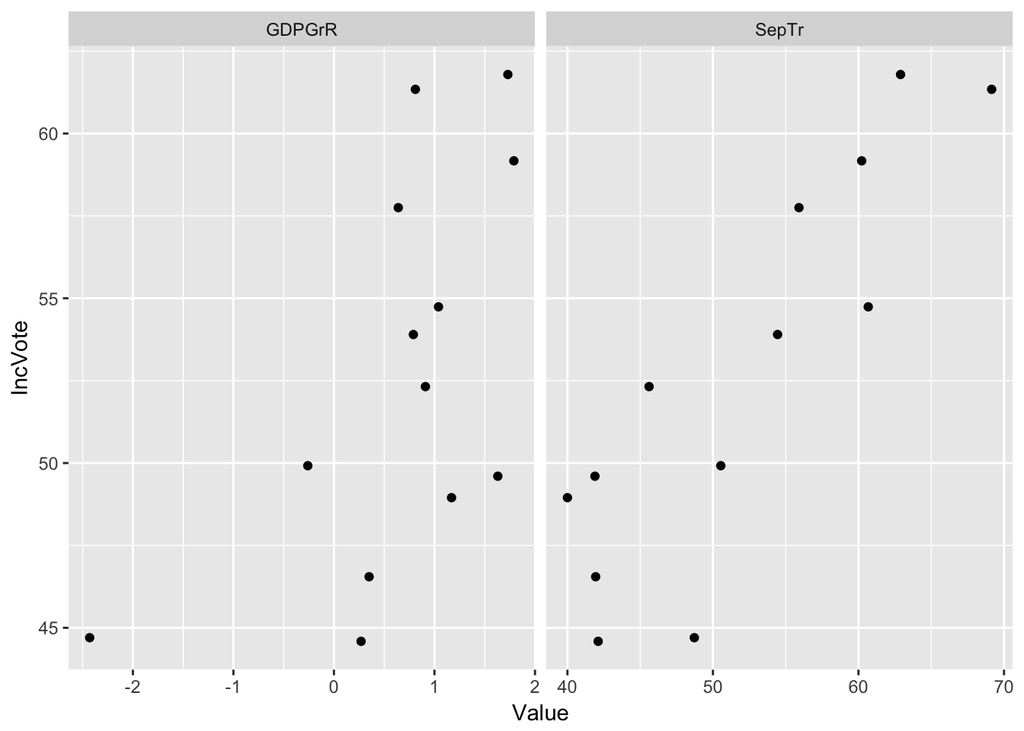

```
##
## Call:
## lm(formula = IncVote ~ SepTr + GDPGrR, data = campbell)
##
## Residuals:
##     Min      1Q  Median      3Q     Max
## -3.1945 -0.4314 -0.2360  0.8862  3.0590
##
## Coefficients:
##             Estimate Std. Error t value Pr(>|t|)
## (Intercept) 25.75387    2.95317   8.721 5.49e-06 ***
## SepTr        0.49173    0.05716   8.602 6.20e-06 ***
## GDPGrR       2.25706    0.49211   4.587    0.001 **
## ---
## Signif. codes:  0 '***' 0.001 '**' 0.01 '*' 0.05 '.' 0.1 ' ' 1
##
## Residual standard error: 1.827 on 10 degrees of freedom
## Multiple R-squared:  0.9223, Adjusted R-squared:  0.9067
## F-statistic: 59.32 on 2 and 10 DF,  p-value: 2.84e-06
```

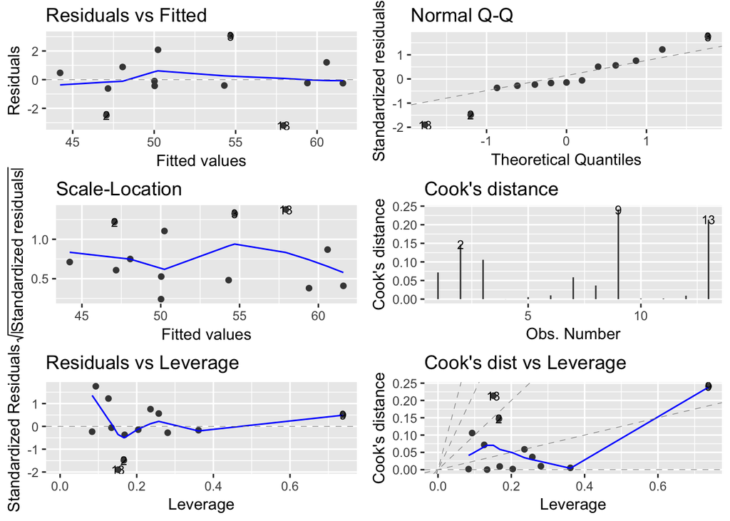

```
##
##  Breusch-Godfrey test for serial correlation of order up to 5
##
## data:  lm.campbell
## LM test = 3.1782, df = 5, p-value = 0.6725
```

## Abramowitzs Model

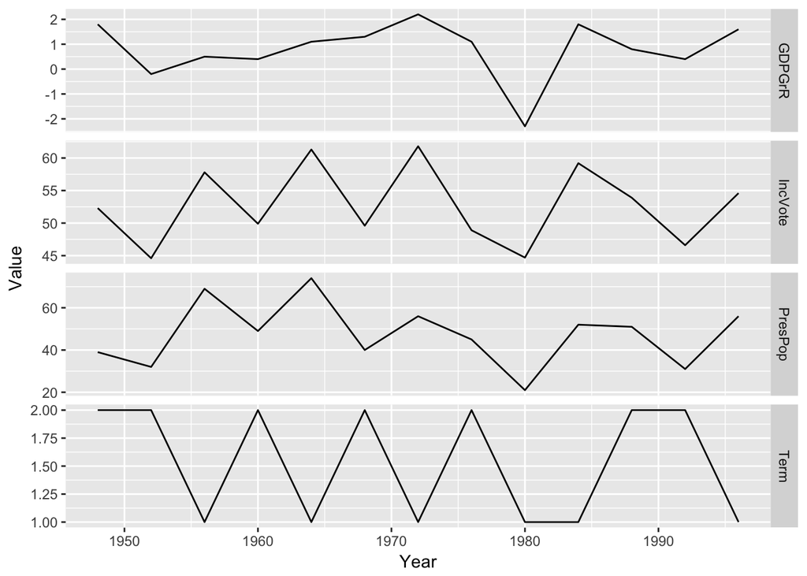

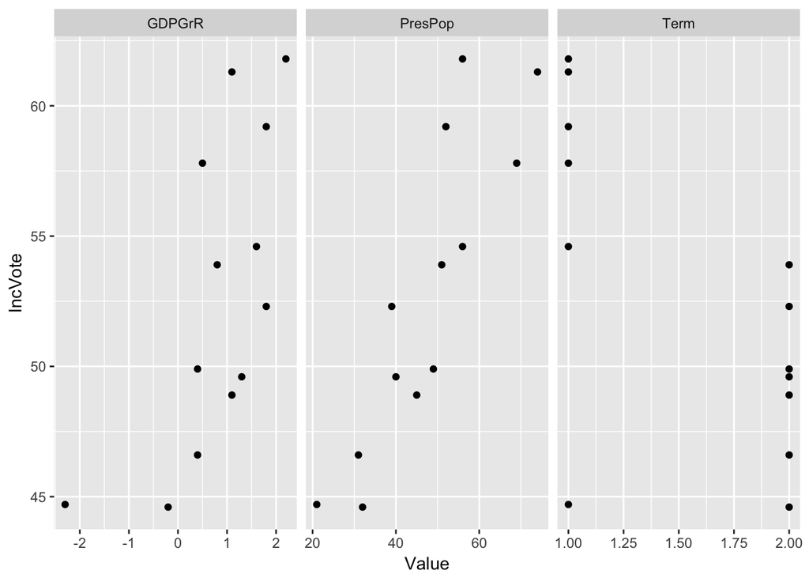

```
##
## Call:
## lm(formula = IncVote ~ PresPop + GDPGrR, data = abramowitz)
##
## Residuals:
##     Min      1Q  Median      3Q     Max
## -3.5397 -1.6970 -0.7514  0.6387  4.6854
##
## Coefficients:
##             Estimate Std. Error t value Pr(>|t|)
## (Intercept)  37.9483     2.9566  12.835 1.55e-07 ***
## PresPop       0.2887     0.0671   4.303  0.00155 **
## GDPGrR        1.3627     0.8691   1.568  0.14800
## ---
## Signif. codes:  0 '***' 0.001 '**' 0.01 '*' 0.05 '.' 0.1 ' ' 1
##
## Residual standard error: 2.897 on 10 degrees of freedom
## Multiple R-squared:  0.8044, Adjusted R-squared:  0.7653
## F-statistic: 20.56 on 2 and 10 DF,  p-value: 0.0002863
```

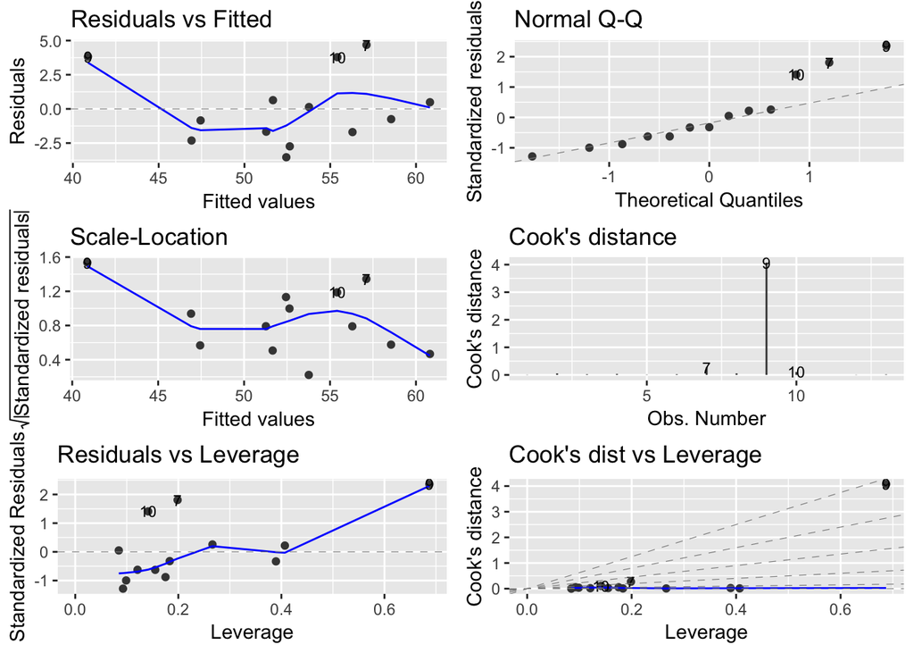

[output not shown]

## Holbrook Model

The Holbrook model assumes that there the predictors of incumbent vote are:  
1. Presential popularity: average percentage of the public who said that they approved of the way the president is handling his job.  
2. Personal finance: measure of restrsopective personal finances based on responses to the Survey of Consumers.  
3. Tenure in office: binary variable coded 1 for presidential candidates whose party has held the White House for two or more terms and 0 for candidates whose party has held the White Whouse for one term.

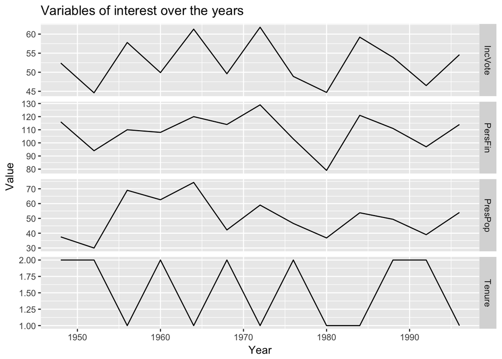

Since we are dealing with we perform the Breusch-Godfrey Test for autocorrelation up to the firth order.

```
##
##  Breusch-Godfrey test for serial correlation of order up to 5
##
## data:  lm.holbrook
## LM test = 5.9254, df = 5, p-value = 0.3135
```

The test indicates that there is no autocorrelation of the error terms, therefore the assumption of the linear model is satisfied.

Following we observe the correlation between the incumbent vote with the presidential popularity and personal finances measures.

|  | IncVote | PresPop | PersFin |
| --- | --- | --- | --- |
| IncVote | 1 | 0.792 | 0.863 |
| PresPop | 0.792 | 1 | 0.588 |
| PersFin | 0.863 | 0.588 | 1 |

We observe how the incumbent vote is highly correlated to the presidential popularity and personal finances measures. Furthermore, we observe how the presidential popularity and personal finances measures have also a high correlation, which might produce multicollinearity problems in the model.

Following we investigate the relationship between the analyzed measures.

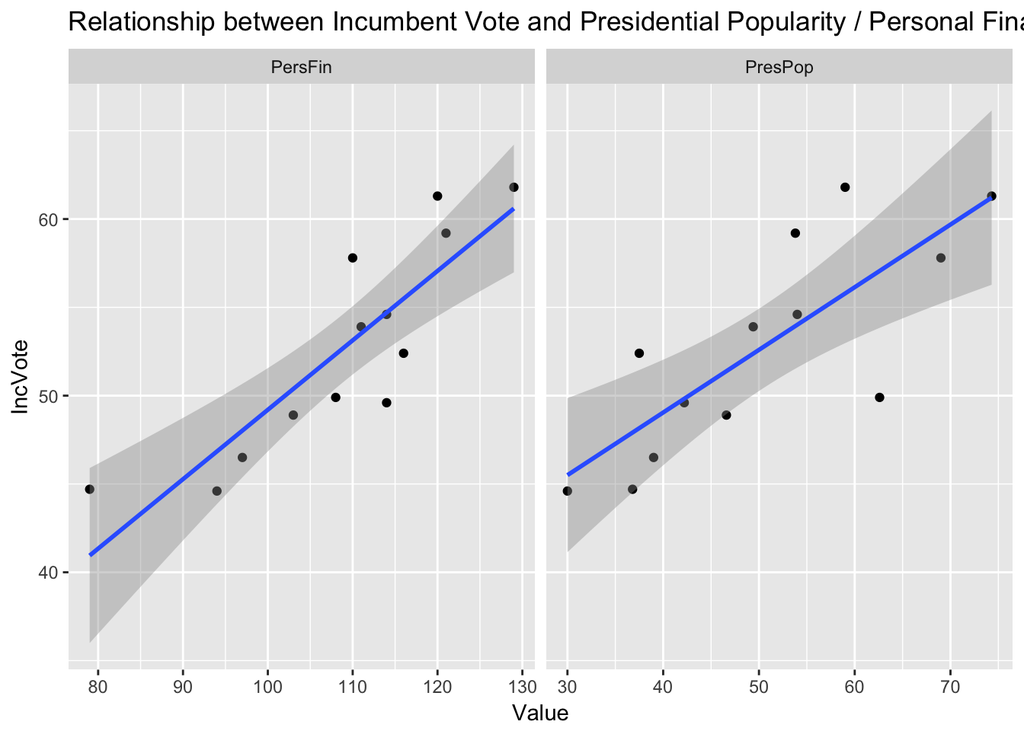

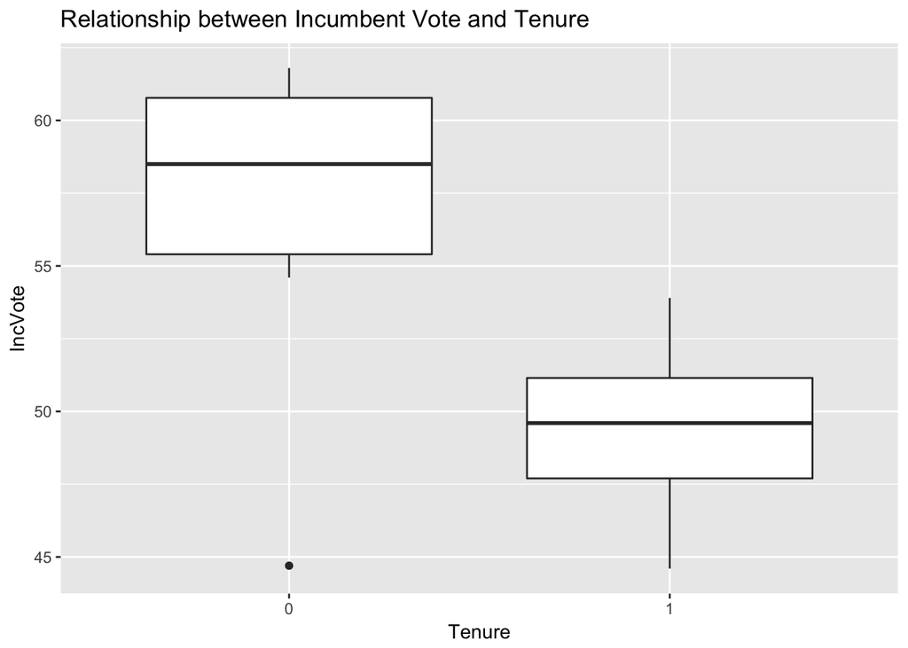

Following we output the results of the following linear model:
$$IncVote = \beta_{0}+\beta_{1}PresPop+\beta_{2}PersFin+\beta_{3}Tenure+\varepsilon$$

|  | *Dependent variable:* |
| --- | --- |
|  | IncVote |
| PresPop | 0.100* |
|  | (0.047) |
| PersFin | 0.296*** |
|  | (0.041) |
| Tenure1 | -3.995*** |
|  | (1.002) |
| Constant | 17.606*** |
|  | (3.865) |
| Observations | 13 |
| R<sup>2</sup> | 0.953 |
| Adjusted R<sup>2</sup> | 0.937 |
| Residual Std. Error | 1.505 (df = 9) |
| F Statistic | 60.332*** (df = 3; 9) |
| *Note:* | p<0.1; p<0.05; p<0.01 |

As we can observe, only the coefficients PersFin and Tenure are statistically significant. This results is not surprising as PresPop and PersFin had a high correlation, meaning that somehow there were explaining the same variability.  
Following we analyze the residuals and verify the model assumptions.

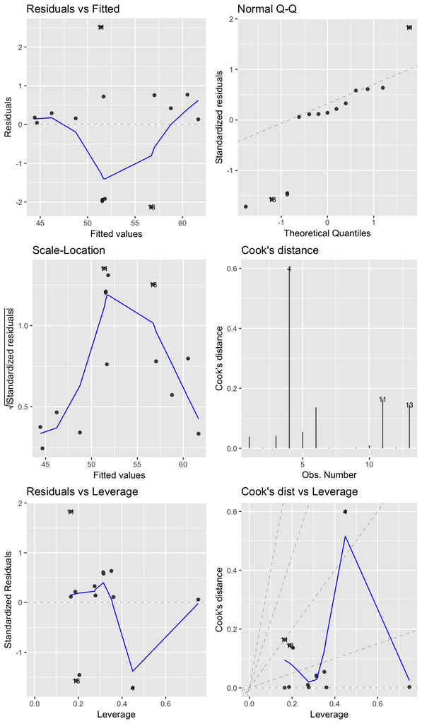

As we can observe there the assumptions of normality and homoscedasticity are not satisfied.

Following we determine whether there are some influential or outliers observations. We will use the following cutoffs to identify these observations:  
1. Cutoff CooksD 4/13 = 0.3 2. Cutoff hat values (2*4)/13 = 0.6

```
##   IncVote PresPop PersFin Tenure  .fitted  .se.fit      .resid      .hat
## 1    49.9    62.6     108      1 51.81615 1.008139 -1.91614648 0.4489611
## 2    44.7    36.8      79      0 44.65512 1.302022  0.04487713 0.7488665
##     .sigma     .cooksd  .std.resid
## 1 1.309143 0.599528020 -1.71562148
## 2 1.595537 0.002640906  0.05951913
```

### Proposed Model

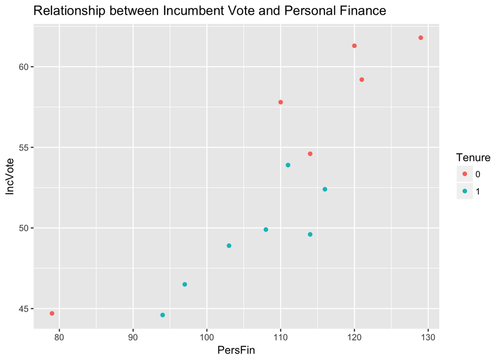

Following we output the results of the following linear model:
$$IncVote = \beta_{0}+\beta_{1}PersFin+\beta_{2}Tenure+\varepsilon$$

|  | *Dependent variable:* |
| --- | --- |
|  | IncVote |
| PersFin | 0.345*** |
|  | (0.040) |
| Tenure1 | -5.087*** |
|  | (1.004) |
| Constant | 17.833*** |
|  | (4.501) |
| Observations | 13 |
| R<sup>2</sup> | 0.929 |
| Adjusted R<sup>2</sup> | 0.914 |
| Residual Std. Error | 1.753 (df = 10) |
| F Statistic | 64.995*** (df = 2; 10) |
| *Note:* | p<0.1; p<0.05; p<0.01 |

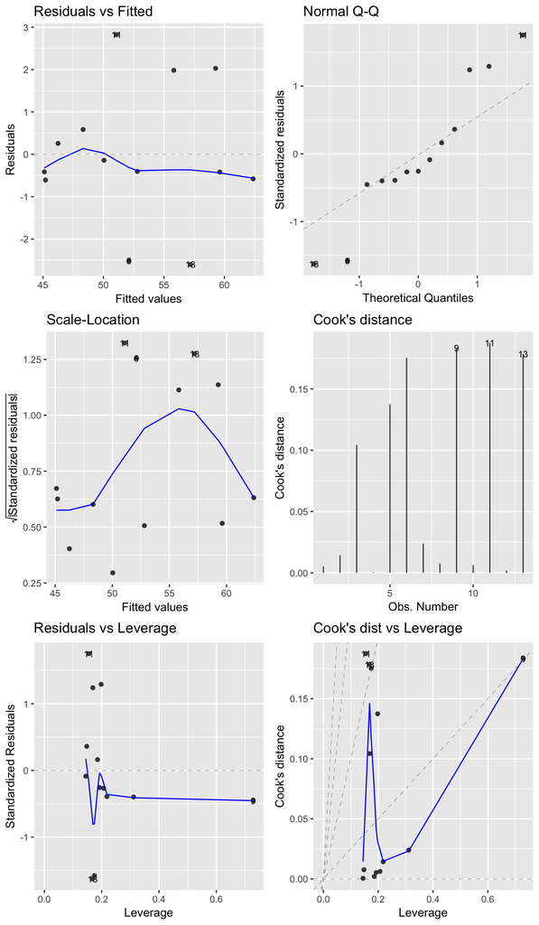

## Lockerbie Model

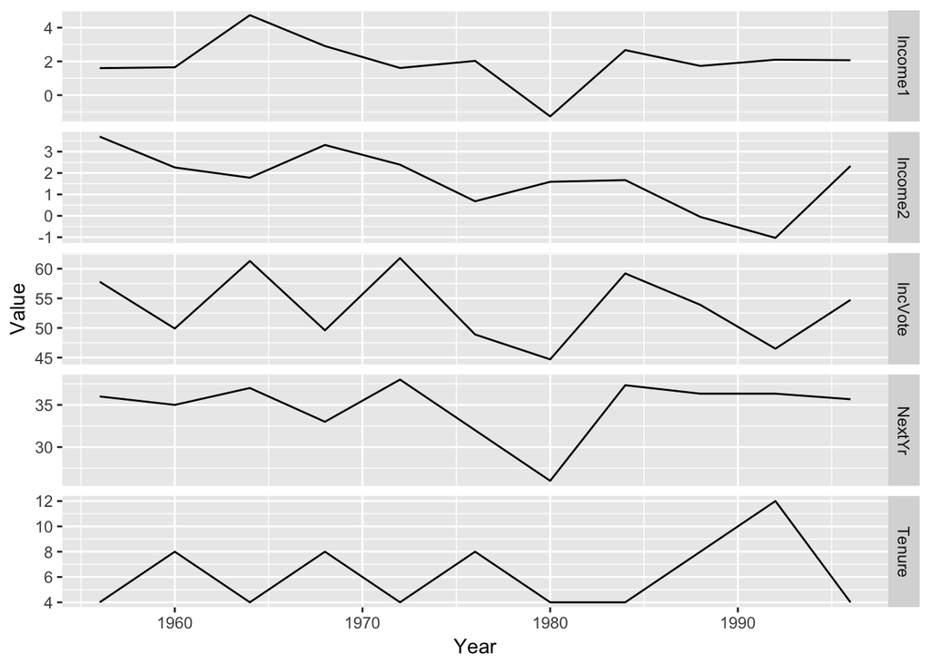

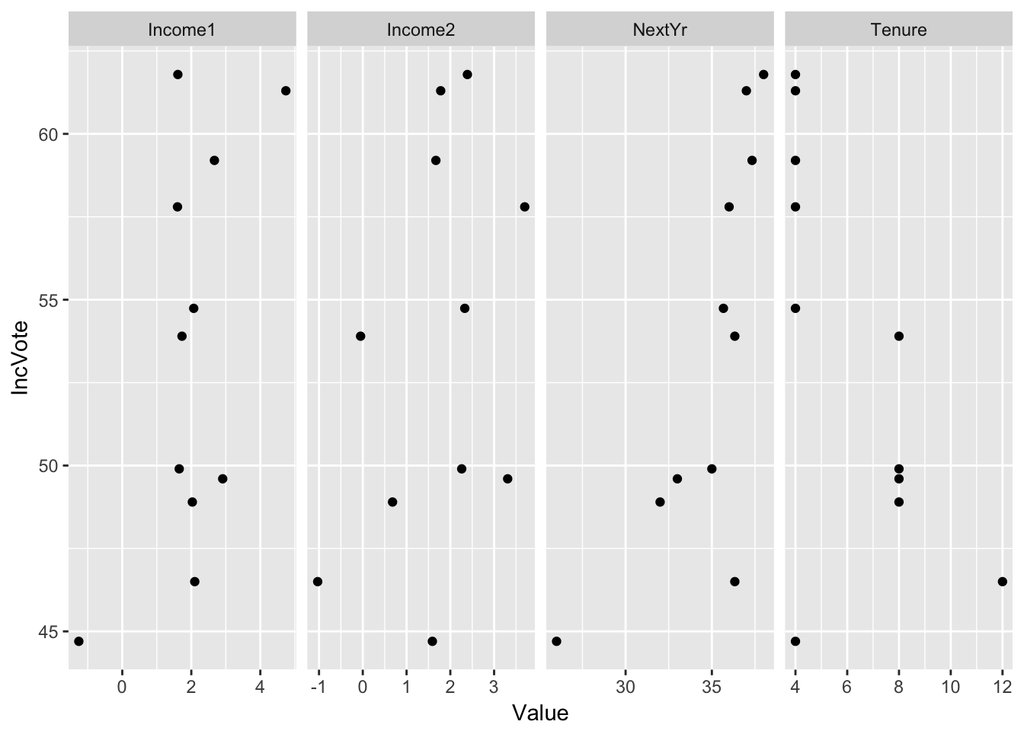

```
##
## Call:
## lm(formula = IncVote ~ Income1 + Income2 + NextYr + Tenure, data = lockerbie)
##
## Residuals:
##     Min      1Q  Median      3Q     Max
## -2.8349 -0.8041  0.4039  0.7211  1.8968
##
## Coefficients:
##             Estimate Std. Error t value Pr(>|t|)
## (Intercept)  22.3508     7.2311   3.091  0.02136 *
## Income1       0.6352     0.5136   1.237  0.26235
## Income2      -0.1836     0.4923  -0.373  0.72200
## NextYr        1.1251     0.2103   5.351  0.00174 **
## Tenure       -1.4488     0.2489  -5.820  0.00113 **
## ---
## Signif. codes:  0 '***' 0.001 '**' 0.01 '*' 0.05 '.' 0.1 ' ' 1
##
## Residual standard error: 1.661 on 6 degrees of freedom
## Multiple R-squared:  0.9538, Adjusted R-squared:  0.923
## F-statistic: 30.95 on 4 and 6 DF,  p-value: 0.0003814
```

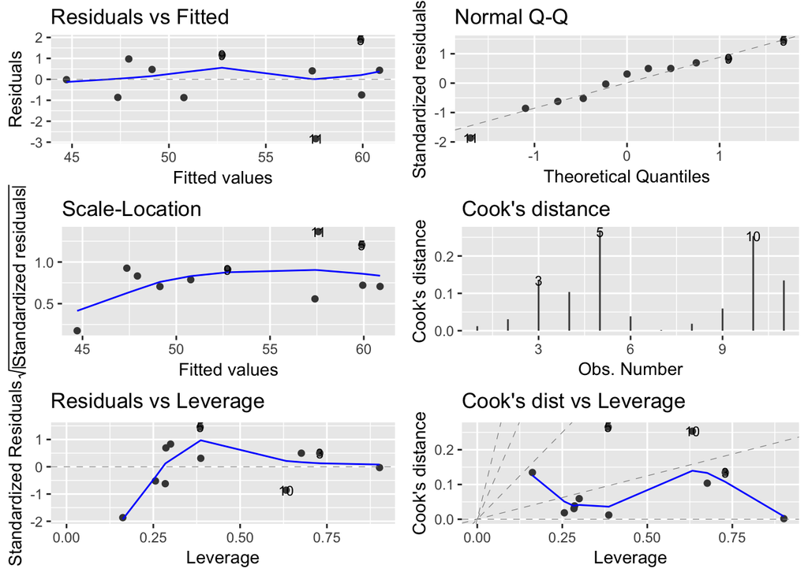

```
##
##  Breusch-Godfrey test for serial correlation of order up to 5
##
## data:  lm.lockerbie
## LM test = 9.9592, df = 5, p-value = 0.0764
```